# Reproducible Research Project

### Question 5.

Are there differences in activity patterns between weekdays and weekends?

For this part the weekdays() function may be of some help here. Use the dataset with the filled-in missing values for this part.

##### 1. َCreate a new factor variable in the dataset with two levels – “weekday” and “weekend” indicating whether a given date is a weekday or weekend day.

```r
# as_tibble(Activity1) # row dataset with NAs
# ActfillingInt # filled dataset without NAs Dataset

ActWdays<- ActfillingInt

# added a column of days
ActWdays$wdays <- weekdays(as.POSIXlt(ActfillingInt$date))

# label the wdays based on Weekdays and Weekend
ActWdayType <- ActWdays%>% mutate(wday_type = ifelse(wdays %in% c("Saturday", "Sunday"),
                                                     "Weekend",
                                                     "Weekdays"))
unique(ActWdayType$wday_type)
```

```
## [1] "Weekdays" "Weekend"
```

#### 2. Make a panel plot:

Make a panel plot containing a time series plot (i.e. type = “l” of the 5-minute interval (x-axis) and the average number of steps taken, averaged across all weekday days or weekend days (y-axis).

See the README file in the GitHub repository to see an example of what this plot should look like using simulated data.

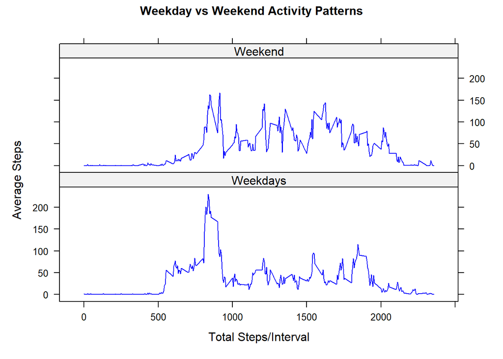

```r
# created a dataset that is grouped by interval and mean of step is calculated for day types.
Act8Wdays <- ActWdayType %>% group_by(interval, wday_type) %>%
  summarise(meanSteps = mean(steps),
            .groups = "drop" )

library(lattice)
xyplot(meanSteps ~ interval | wday_type,
       data = Act8Wdays,
       type = "l",
       layout = c(1,2),
       col = "blue",
       xlab = "Total Steps/Interval",
       ylab = "Average Steps",
       main = "Weekday vs Weekend Activity Patterns",
       par.settings = list(
         par.main.text = list(cex = 1)))
```